```python
from IPython.display import HTML

# Toggle butten to hide the code from the notebook
HTML('''<script>
code_show=true;
function code_toggle() {
 if (code_show){
 $('div.input').hide();
 } else {
 $('div.input').show();
 }
 code_show = !code_show
}
$( document ).ready(code_toggle);
</script>
<form action="javascript:code_toggle()"><input type="submit" value="Click here to toggle on/off the raw code."></form>''')
```

# Winter Olympic Games Data Analysis

By Vincent Huang

```python
import numpy as np
import scipy as sp
import scipy.spatial.distance as spd
import scipy.cluster.hierarchy as sph
import sklearn as sk
import sklearn.cluster as skc
import sklearn.metrics as skm
import pandas as pd
import matplotlib.pyplot as plt
import seaborn as sns
from sklearn.neighbors import KNeighborsClassifier
import sklearn.preprocessing as skp
import random

import warnings
warnings.filterwarnings('ignore')
```

## Introduction

2022 is the year of Tiger, as well as the year of the Olympic Winter Games Beijing 2022. As is known to all, the Winter Olympic Games are the most important winter sports competition in the world. Each Winter Olympics seems to make people full of excitement and energy in the winter and unite the world together. According to the International Olympic Committee's report, so far China has attracted over 300 million people engaged in winter sports in about 2000 ski resorts and ice rinks through the hosting of the Olympic Winter Games Beijing 2022 [1], which is an extraordinary achievement for the global winter sport and raise the global participation of winter sport to an unprecedented level.

In this piece of analysis, here I aimed at analyzing the Winter Olympic Games data to provide insights for the development of Olympics and the performance of the athletes in all diversity. And finally, I tried to build a prediction model of winter sports attended by the athletes in Winter Olympic Games.

## Dataset and Data Wrangling

I obtained the Olympics dataset from Kaggle [2], which contains two CSV files. The main file *athlete_events.csv* contains 271116 rows and 15 columns, including all the athletes' records in summer Games from Athens 1896 to Rio 2016 and winter Games from Chamonix 1924 to Sochi 2014. Due to my focus on the Winter Olympics, I only extracted the Winter Olympics records which contain 48564 records to analyze in this piece. The second file *noc_regions.csv* provides the mapping relationship between the variables *NOC* and *region*. According to the license shown in the Kaggle, the creator of the dataset has dedicated the dataset to the public domain by waiving all the rights. So I can use the dataset legally for academic analysis purposes.

The dataset variables explanations:

- **ID**: Unique number for each athlete
- **Name**: Athlete's name
- **Sex**: Male or Female
- **Age**: The age of athlete
- **Height**: The height of athlete in centimeters
- **Weight**: The weight of athlete in kilograms
- **Team**: Team name of athlete
- **NOC**: The National Olympic Committee of athlete (3 letter code)
- **Games**: The year and season of the Olympic Games that the athlete participated
- **Year**: The year the Olympic Games held
- **Season**: Summer or Winter
- **City**: The host city of Olympic Games
- **Sport**: The sports included in Olypic Games
- **Event**: The events in different sports
- **Medal**: Gold, Silver, Bronze, or NA
- **region**: The country of athlete

As for the data wrangling, since the dataset is relatively clean with some null values having few impacts on my analysis of interests, there is no need to clean the dataset. In terms of my analysis questions of interests, I kept all the columns in file *athlete_events.csv* and merged the two files on the *NOC* column to add the column of *region* for all the athletes, by the tool of Tableau Prep.

```python
winter = pd.read_csv('/content/drive/MyDrive/data605 individual project/Winter Olympics Data.csv')
display(winter.head(),'Demo of the Winter Olympics data')
```

|  | City | Event | Games | ID | Medal | Name | NOC | Region | Season | Sex | Sport | Team | Year | Age | Height | Weight |
| --- | --- | --- | --- | --- | --- | --- | --- | --- | --- | --- | --- | --- | --- | --- | --- | --- |
| 0 | Sankt Moritz | Bobsleigh Men's Two | 1948 Winter | 33540 | NaN | J. Henri Evrot | FRA | France | Winter | M | Bobsleigh | France-1 | 1948 | 46.0 | NaN | NaN |
| 1 | Sankt Moritz | Bobsleigh Men's Four | 1948 Winter | 33540 | NaN | J. Henri Evrot | FRA | France | Winter | M | Bobsleigh | France-2 | 1948 | 46.0 | NaN | NaN |
| 2 | Sapporo | Alpine Skiing Men's Downhill | 1972 Winter | 33556 | NaN | Ross Alain Ewington | NZL | New Zealand | Winter | M | Alpine Skiing | New Zealand | 1972 | 24.0 | 175.0 | 73.0 |
| 3 | Sapporo | Alpine Skiing Men's Giant Slalom | 1972 Winter | 33556 | NaN | Ross Alain Ewington | NZL | New Zealand | Winter | M | Alpine Skiing | New Zealand | 1972 | 24.0 | 175.0 | 73.0 |
| 4 | Sapporo | Alpine Skiing Men's Slalom | 1972 Winter | 33556 | NaN | Ross Alain Ewington | NZL | New Zealand | Winter | M | Alpine Skiing | New Zealand | 1972 | 24.0 | 175.0 | 73.0 |

```
'Demo of the Winter Olympics data'
```

## Methodology and Tools

1. Wrangled data through Tableau Prep, including filtering out the summer Olympics records and joining the two data files.
2. Extracted the data regarding different questions of interest and visualized the data for analysis by Tableau.
3. Built the prediction model for sports in Winter Olympics by leveraging the pandas, Numpy, matplotlib, scipy, and sklearn libraries in Python.
4. Edited the essay in Google Colab.

## 1. How do the numbers of participating nations and athletes vary over time?

The following dual combination chart shows the number of countries and athletes that participated in the Winter Olympics each time. Blue presents the number of participating athletes, and orange is the number of countries.

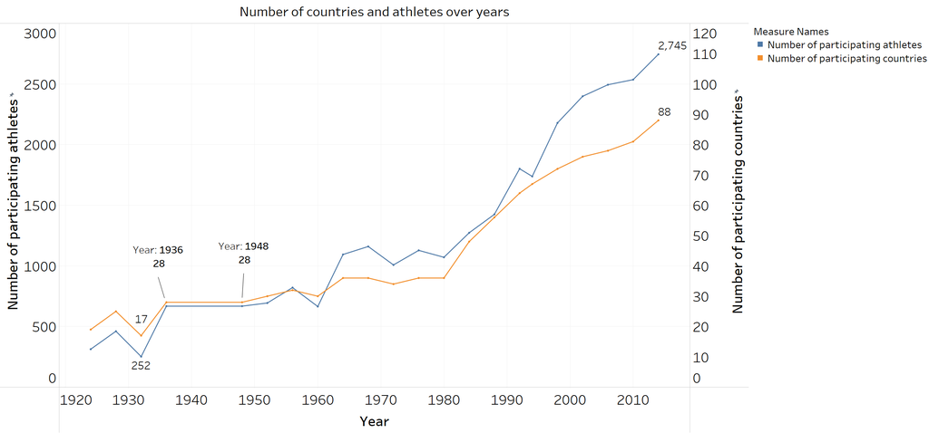

## 2. How are the participating countries distributed over the world?

[figure not shown]

This is a world map showing the distribution of the countries participating in the Winter Olympics over the world as well as their participation counts. Obviously, most countries are located outside the tropics and subtropics or at least have territories outside the tropics and subtropics. It looks like most countries in Europe and North America have participated in most Winter Olympic Games, some of which have participated in all the Olympics, such as Canada, the USA, France, Sweden, Finland etc. However, it's interesting to find that there are still a few countries in the tropics and subtropics that have participated in the Winter Olympics very few times, such as the Philippines, Thailand, Colombia, Ghana etc.

## 3. How are the numbers of sports and events distributed over years?

As for the development of the Winter Olympics, I am also curious about how the diverse competing sports and events changed over time.

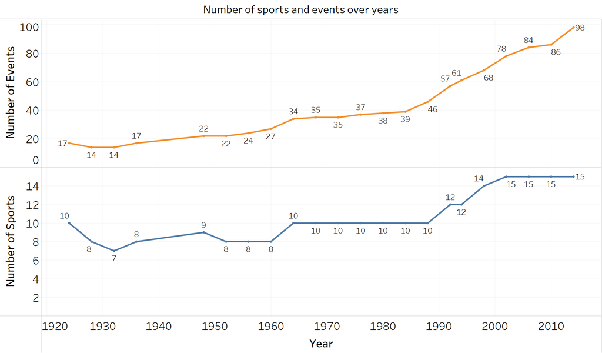

## 4. What countries have better performance in Winter Olympics based on history?

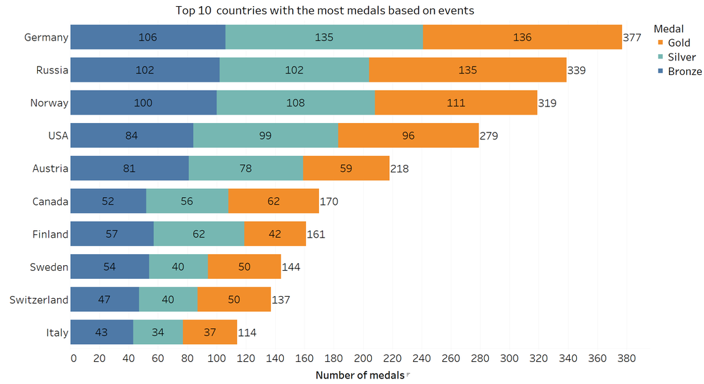

In order to find which countries have had better performance in Winter Olympics in history, I selected the total number of medals for each country which is counted based on event instead of athlete as the benchmark. By this benchmark, I created this chart showing the top 10 countries with the most medals and how many medals they have for 3 different medal classes separately.

From the stacked bar chart above, we have the following interesting findings:

- Surprisingly, Germany had won the most medals in the world in the history of the Winter Olympic Games.
- Germany, Russia, Norway, USA, Austria, Canada, Finland, Sweden, Switzerland, and Italy are the top 10 countries with the most medals.
- Generally, the more medals the country had, the more gold medals it had. But Finland has 42 gold medals which are smaller than Sweden and Switzerland, while Finland's total medal number is larger than that of Sweden and Switzerland, which makes it ranked higher than Sweden and Switzerland.

## 5. What sports are the strengths of the leading countries in the Winter Olympics?

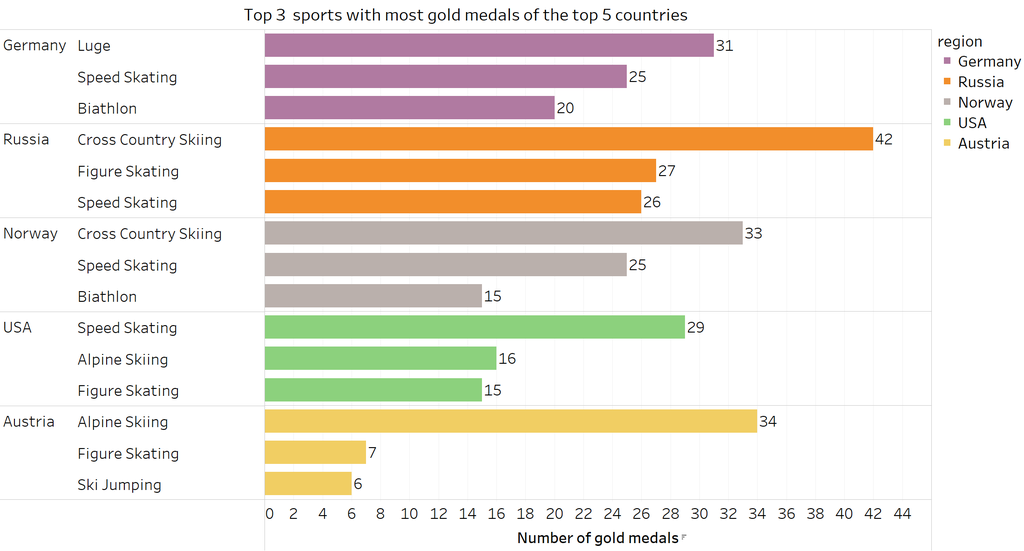

Now that I have found the top ten leading countries in the Winter Olympics, I am further curious about which sports the strengths of the leading countries are. So in order to answer the question, I visualized the related data in this side-by-side bar chart to present the top 3 sports with the most gold medals of the top 5 countries known in the last question. We can see that although different countries have different strengths, there are still some common strengths among them, such as Speed Skating is the strength of all the top 5 except Austria.

## 6. Who are the legendary players in the Winter Olympics history?

Every field has its own legendary figures, so does the Winter Olympics. Here I found out the top 5 legendary players in the Winter Olympics history by ranking the number of gold medals all the athletes had in total.

The bar chart below shows:

- Ole Einar Bjrndalen is the greatest player in Biathlon sport who has won the most gold medals (8 medals）in the Winter Olympics history.
- Viktor An is the greatest player in Short Track Speed Skating sport who has won the second-most gold medals (6 medals) in the Winter Olympics history.
- Lidiya Pavlovna Skoblikova is the greatest player in Speed Skating sport who has also won the second-most gold medals in the Winter Olympics history.
- It's remarkable that the Cross Country Skiing sport has two legendary players Marit Bjrgen and Lyubov Ivanovna Yegorova who have both won the second-most gold medals in the Winter Olympics history.

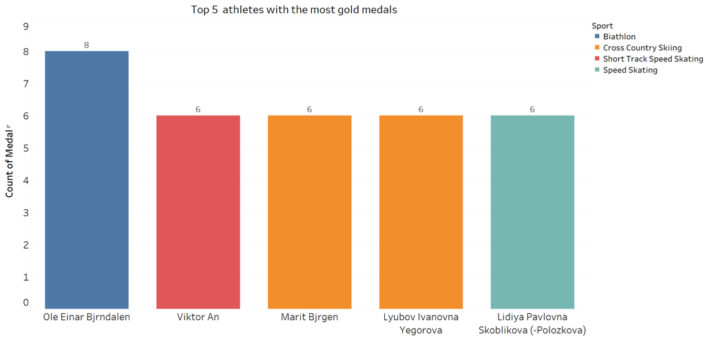

## 7. How are the athletes distributed based on age?

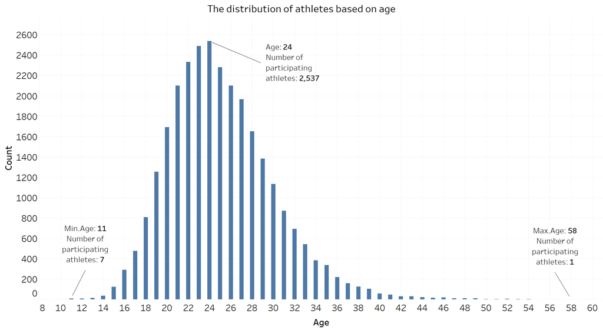

The bar chart shows the age frequency distribution of all the athletes in Winter Olympic Games data with excluding the athletes of null value athlete. We can see that the distribution is a bell-shaped curve. The athletes at the age of 24 have the biggest count. And it's surprising to find that the minimum age of athletes in records is 11 and the maximum age is 58.

## 8. How are the athletes' age distributed based on sport?

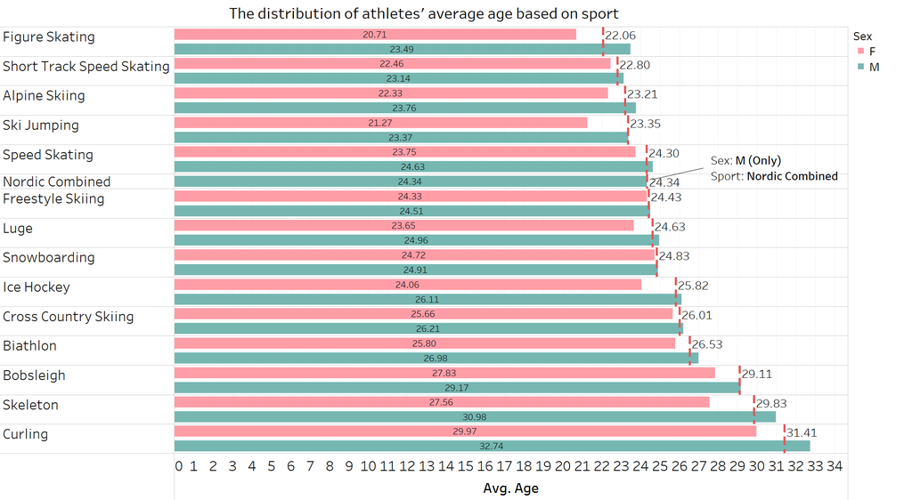

The chart shows the distribution of athletes' average age in different sports. Pink represents the female athletes, and teal stands for the male athletes. The number annotated in the bar denotes the average age for a specific gender, and the number annotated beside a red dash line denotes the average age for a specific sport.

From the chart, we can find that:

- The athletes in Figure Skating have the lowest average age (22.06), whereas the athletes in Curling have the largest average age (31.41).
- The female athletes have lower average age than male athletes in every sport.
- Only male athletes participated in the Nordic Combined sport.

## 9. Are there any Body Mass Index (BMI) differences among the athletes of different sports?

In order to analyze the variation of both weight and height features in the data, I decided to use Body Mass Index (BMI) to take the place of the weight and height features for each athlete. BMI is an easy way to estimate the body fat. According to the BMI definition from CDC [4], I calculated the BMI through the formula as follows:

$BMI=\frac{Weight(kg)}{[Height(m)]^2}$

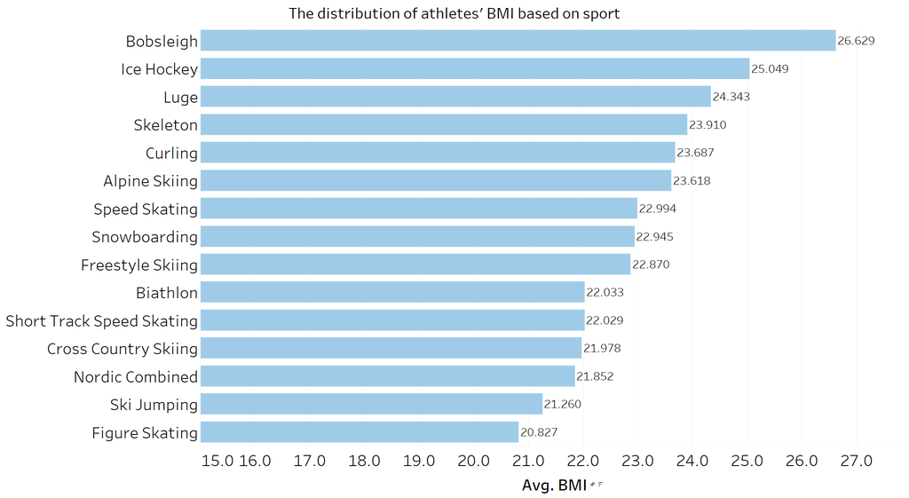

This bar chart shows the BMI distribution of athletes based on the sport. The X-axis stands for the average BMI. From the chart, we can see that:

- The Bobsleigh athletes have the largest average BMI, while the Figure Skating athletes have the smallest average BMI.
- Although most sports' average BMIs are quite different from each other, there are several sports having very close average BMIs, such as Speed Skating, Snowboarding, and Freestyle Skiing.
- The BMIs of the athletes in Bobsleigh and Ice Hockey indicate that most players in these two sports would be evaluated as overweight in terms of the criterion from CDC (BMI>25) [4].

## 10. How do the Winter Olympics athletes' BMIs differ based on age?

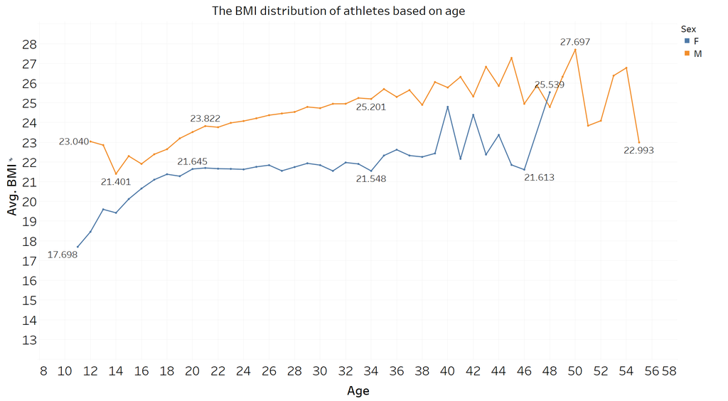

The line chart above is about the BMI distribution of athletes based on age. From this chart, we can find that the average BMI of male athletes increases gradually with the increase of age, while the female athletes' average BMI is relatively steady between the age of 18 and 38. And the average BMI of male athletes is higher than that of female athletes.

Besides, there is a drastic fluctuation for the average BMI of both male and female athletes when the age is beyond 40. I think it's because the sample size of the older athletes is too small, as shown in the chart of Question 7. According to the chart of Question 7, most athletes are in the 15-38 age range. So here we can conclude that most Winter Olympics athletes have their BMIs below 25 and have healthy weights in terms of the criterion from CDC [4].

## 11. Can we predict which sport an athlete participates in based on some features of the dataset?

According to the previous analysis results of BMI, Sex, Age, and Sport features in the dataset, it can be concluded that the variables Weight, Height, Sex and Age in the dataset have a relationship with the variable Sport to some degree. So I decided to choose the variables Weight, Height, Sex and Age as predictors to build a prediction model for the response variable Sport.

First, I extracted the sub-data of the columns Sport, Weight, Height, Sex and Age with non-null values. This sub-data contains a total of 15 sports in the Winter Olympic Games, and these sports are the classes of the response variable.

All the classes of the response variable Sport are listed below.

```python
# Extract the columns of interests
winter_subset = winter[['Sport','Sex','Age','Weight','Height']].dropna().reset_index(drop=True)

# The winter sports after the data wrangling
winter_sport = winter_subset['Sport'].unique()
print(winter_sport, '\n', 'The number of winter sports is {}.'.format(len(winter_sport)))
```

```
['Alpine Skiing' 'Cross Country Skiing' 'Speed Skating' 'Figure Skating'
 'Nordic Combined' 'Snowboarding' 'Ice Hockey' 'Short Track Speed Skating'
 'Biathlon' 'Ski Jumping' 'Skeleton' 'Freestyle Skiing' 'Luge' 'Bobsleigh'
 'Curling']
 The number of winter sports is 15.
```

Second, created the dummy variable for the categorical variable Sex.

```python
# Convert Sex column values to binary
winter_subset.Sex[winter_subset.Sex == 'M'] = 1
winter_subset.Sex[winter_subset.Sex == 'F'] = 0

display(winter_subset.head(15))
```

|  | Sport | Sex | Age | Weight | Height |
| --- | --- | --- | --- | --- | --- |
| 0 | Alpine Skiing | 1 | 24.0 | 73.0 | 175.0 |
| 1 | Alpine Skiing | 1 | 24.0 | 73.0 | 175.0 |
| 2 | Alpine Skiing | 1 | 24.0 | 73.0 | 175.0 |
| 3 | Alpine Skiing | 1 | 22.0 | 76.0 | 174.0 |
| 4 | Alpine Skiing | 1 | 22.0 | 76.0 | 174.0 |
| 5 | Alpine Skiing | 1 | 19.0 | 78.0 | 178.0 |
| 6 | Alpine Skiing | 1 | 19.0 | 78.0 | 178.0 |
| 7 | Alpine Skiing | 1 | 19.0 | 78.0 | 178.0 |
| 8 | Alpine Skiing | 1 | 21.0 | 95.0 | 190.0 |
| 9 | Alpine Skiing | 1 | 21.0 | 95.0 | 190.0 |
| 10 | Alpine Skiing | 1 | 21.0 | 95.0 | 190.0 |
| 11 | Cross Country Skiing | 0 | 20.0 | 62.0 | 170.0 |
| 12 | Cross Country Skiing | 0 | 20.0 | 62.0 | 170.0 |
| 13 | Cross Country Skiing | 0 | 24.0 | 62.0 | 170.0 |
| 14 | Cross Country Skiing | 0 | 24.0 | 62.0 | 170.0 |

Third, normalized the columns Weight, Height, Sex and Age.

```python
# Standardize the data
targetdata = winter_subset.drop(['Sport'], axis=1)
scaler = skp.StandardScaler()
scaled_data = scaler.fit_transform(targetdata)
scaled_data = pd.DataFrame(scaled_data)
scaled_data.columns = targetdata.columns
scaled_data.head()
```

|  | Sex | Age | Weight | Height |
| --- | --- | --- | --- | --- |
| 0 | 0.714256 | -0.237595 | 0.183967 | 0.043344 |
| 1 | 0.714256 | -0.237595 | 0.183967 | 0.043344 |
| 2 | 0.714256 | -0.237595 | 0.183967 | 0.043344 |
| 3 | 0.714256 | -0.669019 | 0.429848 | -0.072973 |
| 4 | 0.714256 | -0.669019 | 0.429848 | -0.072973 |

Then I built the prediction model based on training data by K-Nearest Neighbors classifier and evaluated the prediction performance by calculating the accuracy and plotting the confusion matrix.

The following are the accuracy rate and confusion matrix of the model respectively.

```python
# Set test data and train data
random.seed(2022)
predictor_train, predictor_test, sport_train, sport_test = sk.model_selection.train_test_split(
    scaled_data, winter_subset['Sport'], test_size=0.1, random_state=random.randint(0,1000))

# K-Nearest Neighbors classifier
winter_neigh = KNeighborsClassifier(n_neighbors=5)
winter_neigh.fit(predictor_train, sport_train)
winter_neigh_predictions_test= winter_neigh.predict(predictor_test)

# Evaluate the prediction performance
skm.accuracy_score(y_true=sport_test,
                   y_pred=winter_neigh_predictions_test)
```

```
0.44348707551951344
```

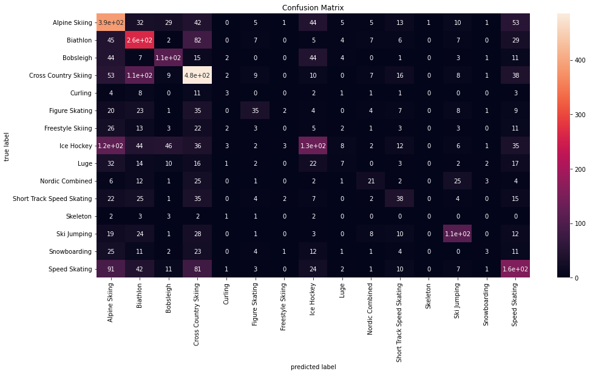

```python
# Compute the confusion matrix
winter_neigh_cfmat = skm.confusion_matrix(
    y_true=sport_test,
    y_pred=winter_neigh_predictions_test,)
winter_neigh_cfmat

# Visualize the confusion matrix
plt.figure(figsize = (16,8))
sns.heatmap(winter_neigh_cfmat,
            xticklabels=winter_neigh.classes_,
            yticklabels=winter_neigh.classes_,
            annot=True)
plt.xlabel('predicted label')
plt.ylabel('true label')
plt.title('Confusion Matrix')
```

Finally, by K-Nearest Neighbors classifier, I got a prediction model for the Sport with an accuracy of nearly 0.4435.

## Conclusions

At last, congratulations on the success of the Beijing 2022 Olympic Winter Games! And hope all the athletes enjoy the Games and have fun!

## References

[1]. IOC President’s speech – Beijing 2022 Opening Ceremony - Olympic News. (2022, February 4). International Olympic Committee. https://olympics.com/ioc/news/ioc-president-s-speech-beijing-2022-opening-ceremony

[2]. 120 Years of Olympic History: Athletes and Results. https://kaggle.com/heesoo37/120-years-of-olympic-history-athletes-and-results. Accessed 15 Feb. 2022.

[3]. En.wikipedia.org. 2022. Winter Olympic Games - Wikipedia. [online] Available at: https://en.wikipedia.org/wiki/Winter_Olympic_Games [Accessed 15 February 2022].

[4]. Centers for Disease Control and Prevention. 2022. All About Adult BMI. [online] Available at: https://www.cdc.gov/healthyweight/assessing/bmi/adult_bmi/index.html [Accessed 15 February 2022].